# Midterm Exam AMA-DS, October 2023. Practice3

Ebner Lena

27/10/2023

# Life expectancy. Countries of the World

LE(age): Life expectancy at exact age $x$ is defined as follows: The average number of remaining years of life expected by a hypothetical cohort of individuals alive at age $x$ who would be subject during the remaining of their lives to the mortality rates of a given year. It is expressed as years.

We have downloaded life expectancy at exact age (for ages from 0 to 100 years) for different countries from the web page of United Nations, Department of Economic and Social Affairs, Extra Life Expectancy Division (2022). World Extra Life Expectancy Prospects 2022, Online Edition.

Other functions can be defined from LE(age):

Here you have the **logarithm of annual increase in expected life length** for year 2021, as functions of age for all the countries in the data set

```r
 #load data
load("./ExamOctober2023.Rdata")
head(LE)
```

```
##        Age
## Country       0       1       2       3       4       5       6       7       8
##      BI 61.6627 63.0588 62.2863 61.5243 60.7719 60.0247 59.2750 58.5125 57.7273
##      KM 63.4174 65.4396 64.7592 63.9982 63.1776 62.3137 61.4187 60.5018 59.5698
##      DJ 62.3049 63.7986 63.0696 62.3327 61.5869 60.8294 60.0560 59.2620 58.4437
##      ER 66.5358 67.5069 66.6639 65.8203 64.9750 64.1257 63.2692 62.4015 61.5194
##      ET 64.9748 66.2860 65.5365 64.7620 63.9660 63.1502 62.3152 61.4610 60.5876
##      KE 61.4270 62.3108 61.6141 60.8061 59.9355 59.0282 58.0970 57.1547 56.2059
##        Age
## Country       9      10      11      12      13      14      15      16      17
##      BI 56.9138 56.0719 55.2062 54.3236 53.4315 52.5365 51.6443 50.7600 49.8869
##      KM 58.6276 57.6790 56.7270 55.7743 54.8232 53.8760 52.9351 52.0023 51.0789
##      DJ 57.6005 56.7343 55.8499 54.9530 54.0493 53.1444 52.2430 51.3493 50.4661
##      ER 60.6219 59.7100 58.7866 57.8558 56.9214 55.9877 55.0584 54.1369 53.2256
##      ET 59.6967 58.7907 57.8734 56.9489 56.0211 55.0942 54.1718 53.2571 52.3524
##      KE 55.2515 54.2935 53.3337 52.3739 51.4155 50.4604 49.5108 48.5697 47.6370
##        Age
## Country      18      19      20      21      22      23      24      25      26
##      BI 49.0267 48.1789 47.3409 46.5097 45.6821 44.8559 44.0298 43.2031 42.3757
##      KM 50.1648 49.2589 48.3588 47.4613 46.5644 45.6664 44.7669 43.8656 42.9630
##      DJ 49.5948 48.7350 47.8846 47.0411 46.2016 45.3640 44.5268 43.6891 42.8505
##      ER 52.3256 51.4363 50.5554 49.6800 48.8075 47.9359 47.0640 46.1914 45.3182
##      ET 51.4589 50.5763 49.7032 48.8373 47.9758 47.1164 46.2573 45.3974 44.5365
##      KE 46.7151 45.8045 44.9024 44.0091 43.1231 42.2458 41.3768 40.5158 39.6634
##        Age
## Country      27      28      29      30      31      32      33      34      35
##      BI 41.5478 40.7196 39.8916 39.0638 38.2363 37.4090 36.5815 35.7537 34.9257
##      KM 42.0596 41.1557 40.2519 39.3487 38.4465 37.5459 36.6471 35.7509 34.8579
##      DJ 42.0110 41.1711 40.3309 39.4910 38.6513 37.8117 36.9721 36.1323 35.2926
##      ER 44.4444 43.5705 42.6964 41.8223 40.9479 40.0729 39.1969 38.3197 37.4414
##      ET 43.6745 42.8118 41.9486 41.0852 40.2217 39.3577 38.4931 37.6278 36.7621
##      KE 38.8191 37.9838 37.1561 36.3369 35.5263 34.7219 33.9267 33.1402 32.3639
##        Age
## Country      36      37      38      39      40      41      42      43      44
##      BI 34.0983 33.2722 32.4487 31.6290 30.8142 30.0044 29.1992 28.3975 27.5979
##      KM 33.9687 33.0837 32.2033 31.3279 30.4578 29.5931 28.7341 27.8812 27.0347
##      DJ 34.4538 33.6166 32.7824 31.9523 31.1275 30.3083 29.4942 28.6841 27.8768
##      ER 36.5628 35.6847 34.8083 33.9353 33.0672 32.2045 31.3469 30.4934 29.6429
##      ET 35.8966 35.0323 34.1703 33.3119 32.4583 31.6099 30.7663 29.9266 29.0898
##      KE 31.5991 30.8432 30.0970 29.3592 28.6295 27.9087 27.1942 26.4862 25.7855
```

[output cut: 33 more lines]

```
## Country     82     83     84     85     86     87     88     89     90     91
##      BI 4.6643 4.3627 4.0834 3.8294 3.6001 3.3918 3.1976 3.0138 2.8401 2.6766
##      KM 4.3209 4.0391 3.7798 3.5495 3.3487 3.1727 3.0121 2.8598 2.7145 2.5757
##      DJ 4.6350 4.3266 4.0415 3.7842 3.5543 3.3477 3.1559 2.9741 2.8024 2.6408
##      ER 5.0810 4.7458 4.4362 4.1567 3.9063 3.6802 3.4696 3.2685 3.0756 2.8908
##      ET 4.8525 4.5244 4.2204 3.9458 3.7002 3.4793 3.2742 3.0796 2.8959 2.7232
##      KE 5.9454 5.5795 5.2395 4.9383 4.6669 4.4251 4.1976 3.9825 3.7738 3.5886
##        Age
## Country     92     93     94     95     96     97     98     99    100
##      BI 2.5229 2.3786 2.2438 2.1184 2.0004 1.8856 1.7745 1.6741 1.5910
##      KM 2.4431 2.3178 2.2012 2.0942 1.9971 1.9094 1.8314 1.7614 1.6961
##      DJ 2.4892 2.3476 2.2163 2.0955 1.9856 1.8866 1.7979 1.7183 1.6467
##      ER 2.7154 2.5515 2.4004 2.2609 2.1231 1.9951 1.8799 1.7718 1.6722
##      ET 2.5615 2.4108 2.2713 2.1431 2.0266 1.9213 1.8261 1.7394 1.6601
##      KE 3.3956 3.2221 3.0582 2.9074 2.7734 2.6494 2.5318 2.4156 2.3153
```

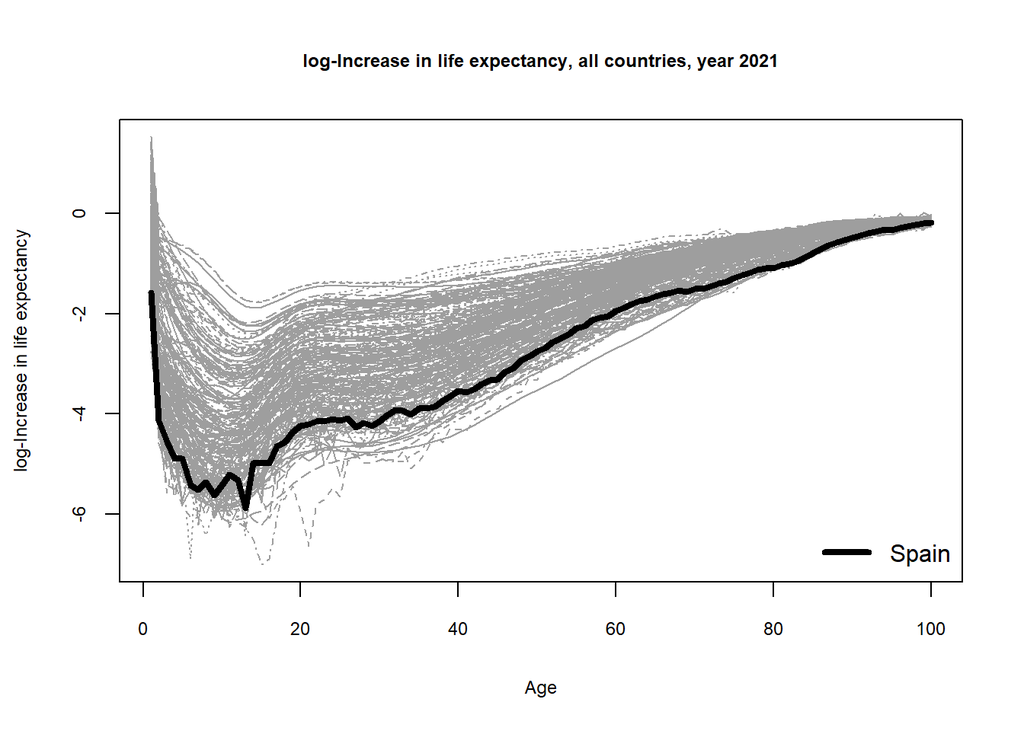

```r
matplot(1:100,t(lgDifLE), type="l",  col=8,
        xlab="Age",ylab="log-Increase in life expectancy",
        main="log-Increase in life expectancy, all countries, year 2021",
        cex.main=.75,cex.lab=.75,cex.axis=.75)
i <- which(rownames(lgDifLE)=='ES')
lines(1:100,lgDifLE[i,],lwd=4, col=1)
legend("bottomright",CtryName[i],lwd=4,col=1,bty="n")
```

The file `ExamOctober2023.Rdata` contains the following data:

- `LE`, a matrix (countries in rows, age in columns) with life expectancy at exact age
- `lgDifLE`, a matrix (countries in rows, age in columns) with logarithms of the annual increase in life expectancy.
- `CtryName`, a vector with the country names.
- `CtryISO2`, a vector with the 2-digits ISO country codes.

# Questions

## 1. Density estimation (2 points out of 10)

Consider the joint distribution of `x=scale(LE[,1])`, `y=scale(lgDifLE[,15])`, that is, the joint distribution of the centered and scaled values of the life expectancy at birth and the log-Increase in life expectancy at the age of 15.

Estimate the joint density of $(x,y)$ using a bivariate Gaussian kernel estimator with equal bandwidths in both dimensions, h=a*c(1,1), with `a` chosen by maximum log-likelihood leave-one-out cross-validation in `seq(0.15,.3,by=0.025)`.

Which is the optimal value of `a`? Give at least two graphical representations of the estimated density function. When it is possible, add the observed points to the graphics.

```r
x <- scale(LE[,1])
y <-scale(lgDifLE[,15])

X <- cbind(x,y)

library(sm)
```

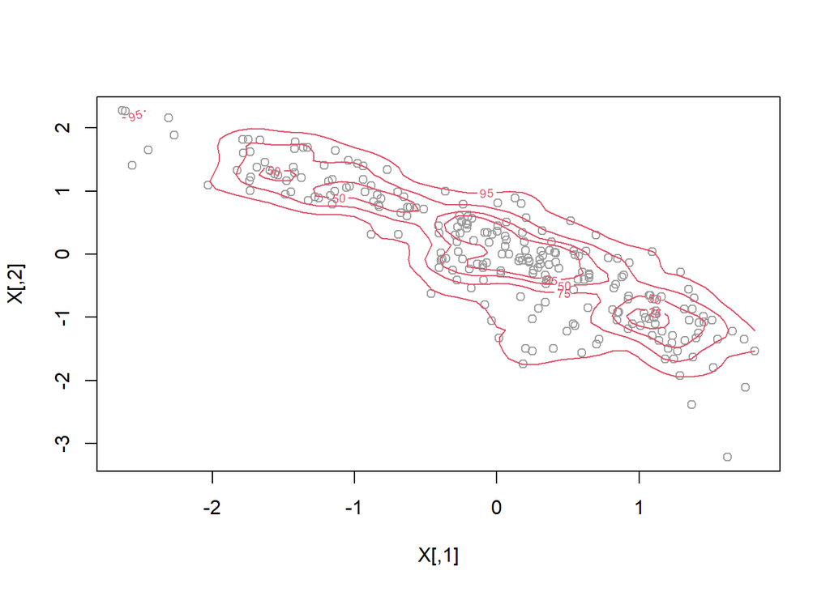

```r
plot(X,col=8)
sm.density(X,h=0.15*c(1,1),display="slice",props=c(25,50,75,95),col=2,add=TRUE)
```

```r
a_values <- seq(0.15,.3,by=0.025)
logLCVa <- numeric(length(a_values))

looCV_log__lik=list()

n <- dim(X)[1]

for (j in 1:a_values){
  a <- a_values[j]
  for (i in 1:n){
    new.point <- matrix(X[i,],ncol=2)
    f.hat.i <- sm.density(X[-i,],h=a*c(1,1),display="none",eval.grid=FALSE,
                    eval.points=new.point)$estimate

     logLCVa[j] <- logLCVa[j] + log(f.hat.i)
  }
}
```

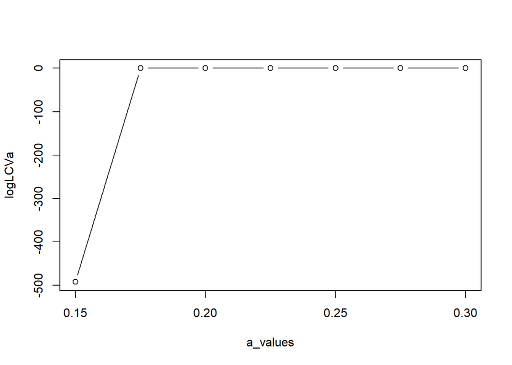

```r
plot(a_values,logLCVa, type="b")
```

```r
best=a_values[which.max(logLCVa)]
print(paste("best b (LOOCV)",best))
```

```
## [1] "best b (LOOCV) 0.175"
```

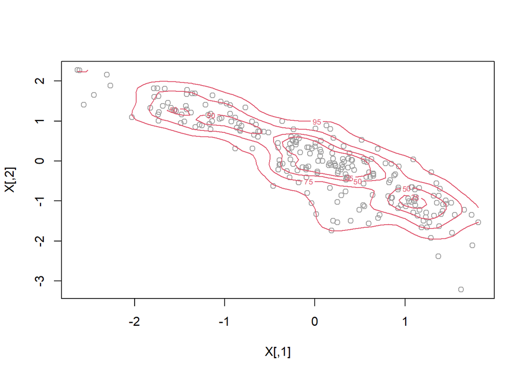

```r
plot(X,col=8)
sm.density(X,h=best*c(1,1),display="slice",props=c(25,50,75,95),col=2,add=TRUE)
```

## Fitting a GMM. (2 points out of 10)

Consider the previous bivariate data set $(x_i, y_i)$, $i=1,\ldots,n$, where $n$ is the number of countries.

- Fit a Gaussian Mixture Model (GMM) to these data choosing the best model by the Bayesian Information Criterion (BIC). Give graphical representations of the estimated model.

```r
library(mclust)
```

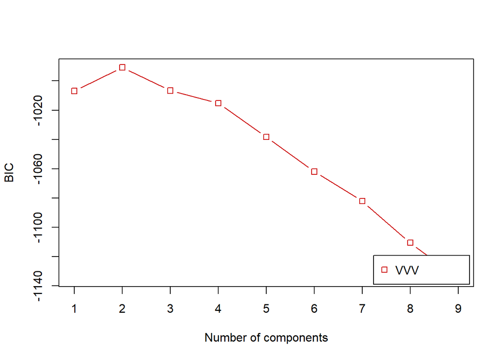

```r
library(sm)
library(fpc)
library(ggplot2)
library(cluster)

rng=2:6
X <- cbind(x,y)
GMM <- Mclust(as.matrix(X), k=3, modelNames = "VVV")

plot(GMM, what="BIC")
```

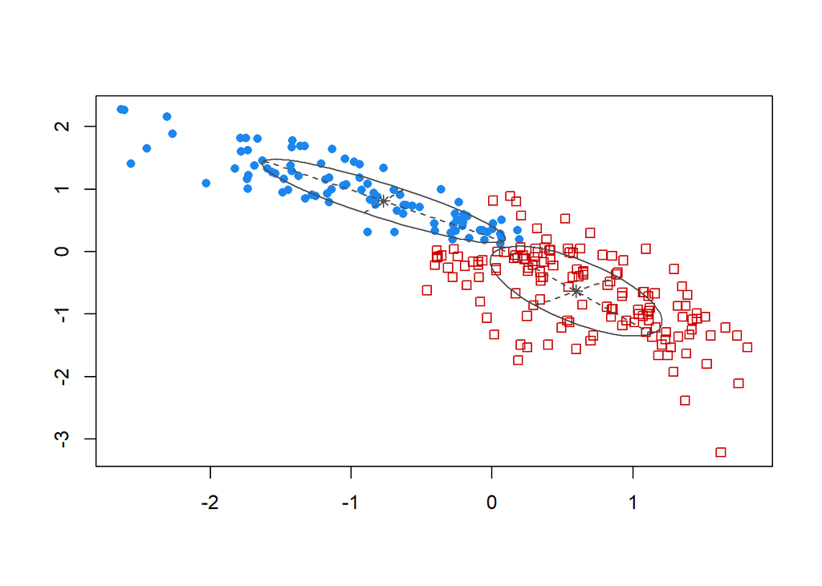

```r
plot(GMM, what="classification")
```

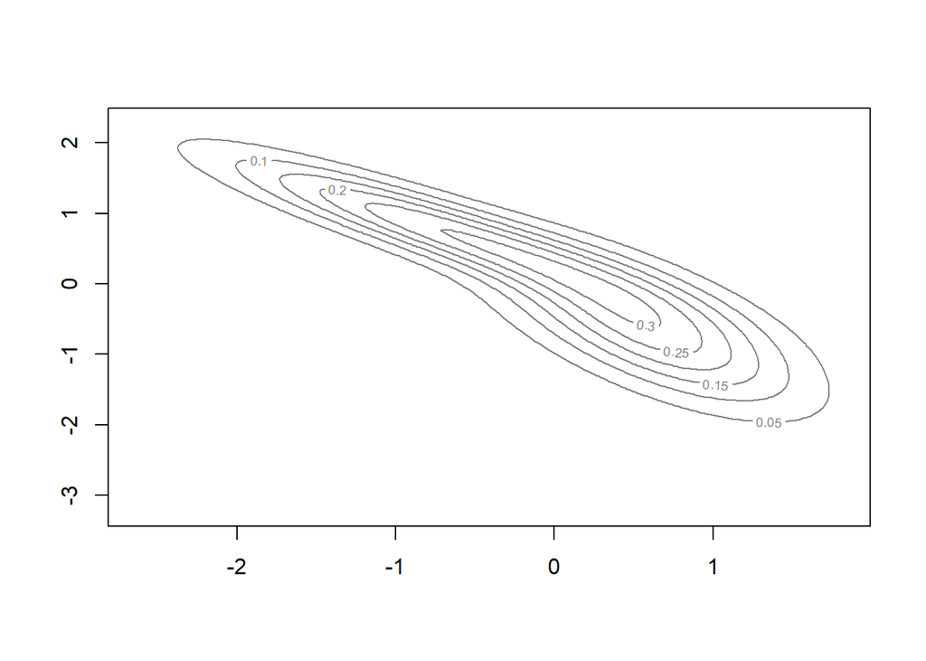

```r
plot(GMM, what="density")
```

- How many mixture components have the fitted model?

```r
summary(GMM,parameters=TRUE)
```

```
## ----------------------------------------------------
## Gaussian finite mixture model fitted by EM algorithm
## ----------------------------------------------------
##
## Mclust VVV (ellipsoidal, varying volume, shape, and orientation) model with 2
## components:
##
##  log-likelihood   n df       BIC       ICL
##       -465.3356 236 11 -990.7734 -1069.884
##
## Clustering table:
##   1   2
##  94 142
##
## Mixing probabilities:
##         1         2
## 0.4370028 0.5629972
##
## Means:
##           [,1]       [,2]
## [1,] -0.769346  0.5971724
## [2,]  0.810902 -0.6294285
##
## Variances:
## [,,1]
##            [,1]       [,2]
## [1,]  0.7467912 -0.5213116
## [2,] -0.5213116  0.4474711
## [,,2]
##            [,1]       [,2]
## [1,]  0.3729693 -0.2977819
## [2,] -0.2977819  0.5147658
```

```r
# the fitted model has 2 mixture components
```

- Have the different components the same variance matrices?

```r
# as seen above the the components have different variance matrices
# Variances:
# [,,1]
#            [,1]       [,2]
# [1,]  0.7467912 -0.5213116
# [2,] -0.5213116  0.4474711
# [,,2]
#            [,1]       [,2]
# [1,]  0.3729693 -0.2977819
# [2,] -0.2977819  0.5147658
```

- How the estimated density by GMM compares with the non-parametric estimator obtained before?

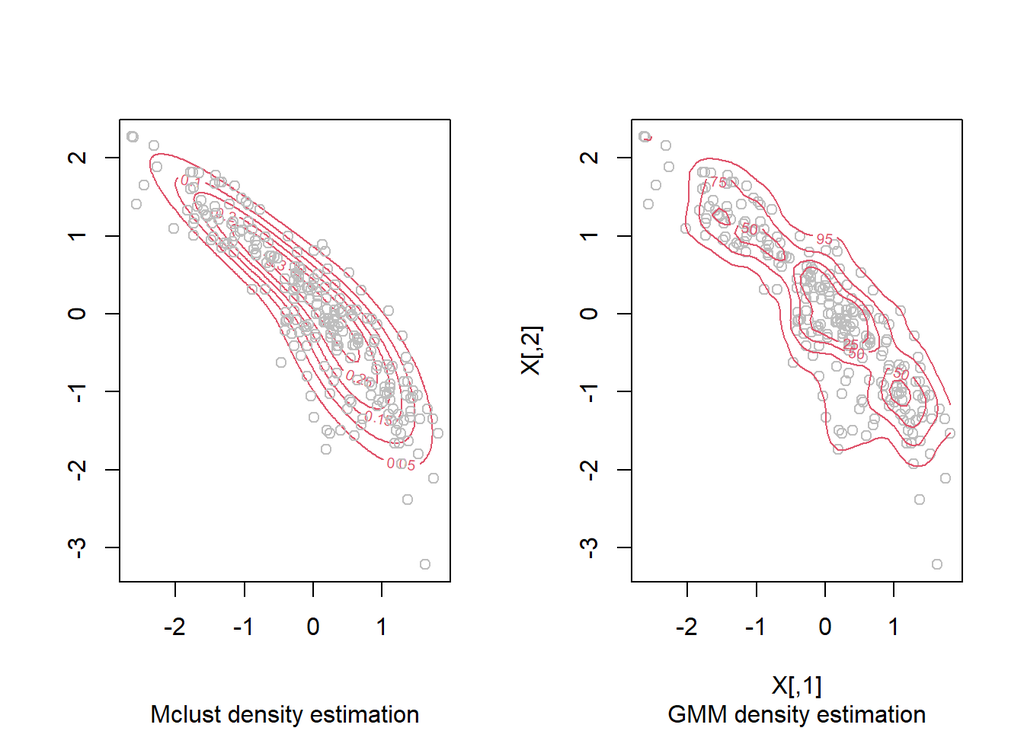

```r
par(mfrow = c(1, 2))

plot(GMM, what="density", sub="Mclust density estimation", col=2)
points(X, col = "grey")

plot(X, sub="GMM density estimation", col = "grey")
sm.density(X,h=best*c(1,1),display="slice",props=c(25,50,75,95),col=2,add=TRUE)
```

- Could you give an interpretation of the clusters identified by the fitted GMM? Mentions some countries belonging to each cluster.

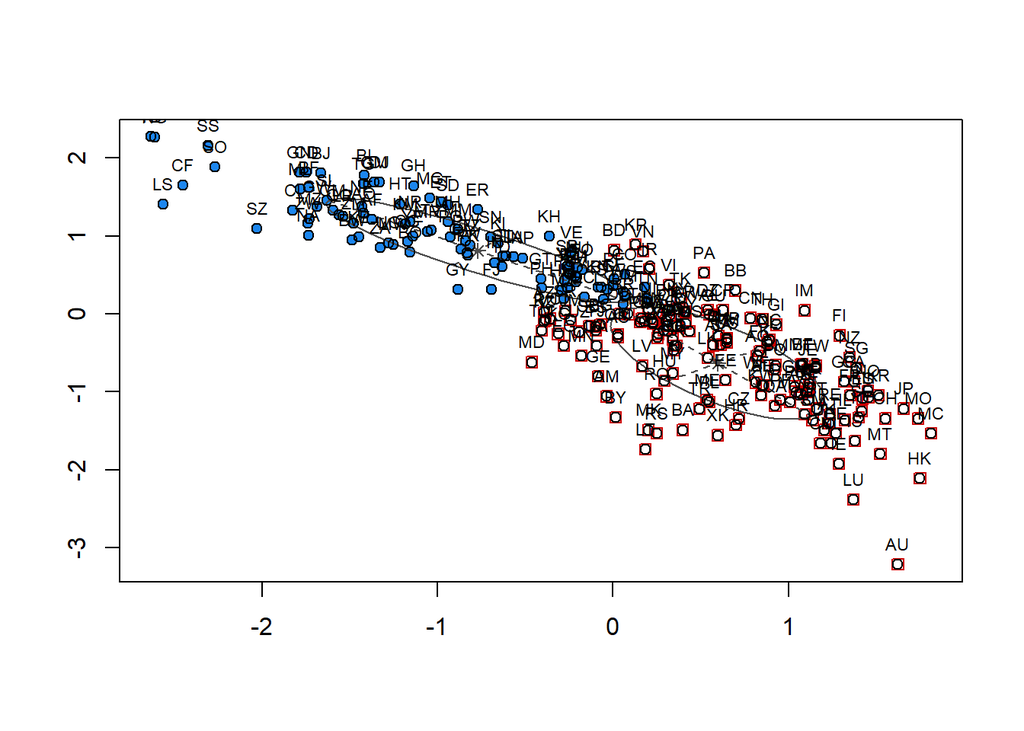

```r
plot(GMM, what="classification")
points(X)
text(X[,1], X[,2], rownames(X), pos = 3, cex = .7)
```

```r
# there are 2 clusters
```

## Db scan

- How many clusters are detected by Dbscan, when using epsilon=0.25 and minPts=4?

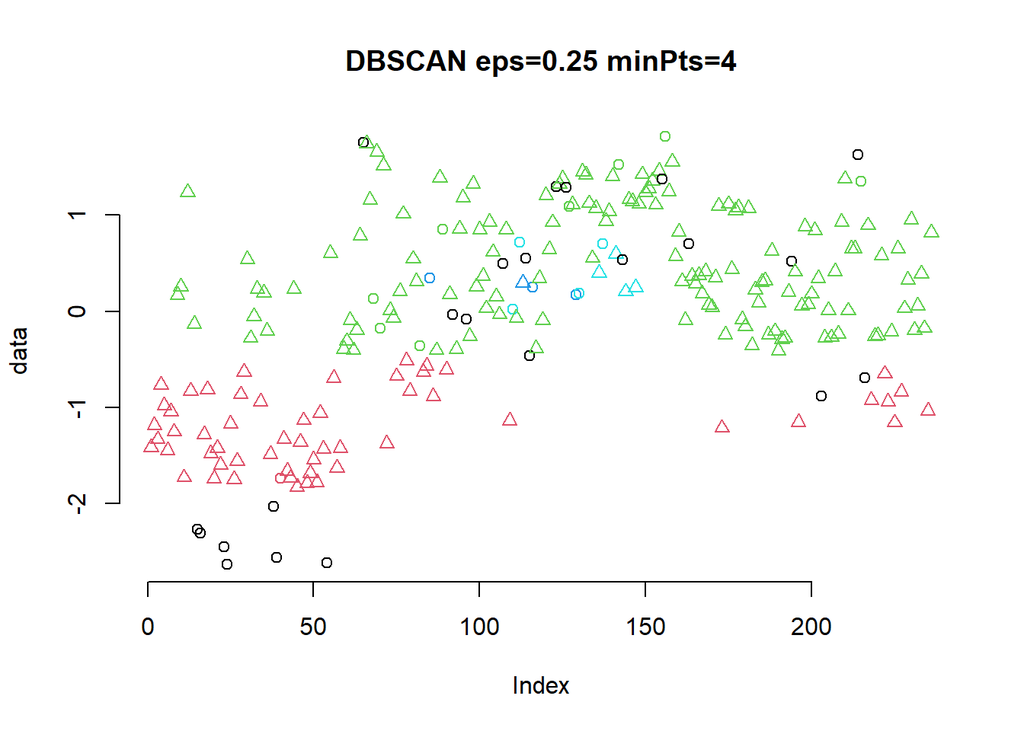

```r
library(fpc)
epsilon <- 0.25
minPts <- 4

dbscan_result <- fpc::dbscan(X, eps = epsilon, MinPts = minPts, showplot = 0)
plot(dbscan_result, x, main = sprintf("DBSCAN eps=%.2f minPts=%d", epsilon, minPts), frame = FALSE)
```

```r
# 4 clusters have been detected by dbcscan
```

- How many outliers have been detected by Dbscan?

```r
dbscan_result
```

```
## dbscan Pts=236 MinPts=4 eps=0.25
##         0  1   2 3 4
## border 22  1   8 3 4
## seed    0 55 138 1 4
## total  22 56 146 4 8
```

```r
# 22 outliers have been detected bz dbscan
```

- Which is the relationship between the clusters identified by Dbscan and those identified by GMM?

## Dimensionality reduction (3 points out of 10)

```r
LCMC <- function(D1,D2,Kp){
  D1 <- as.matrix(D1)
  D2 <- as.matrix(D2)
  n <- dim(D1)[1]
  N.Kp.i <- numeric(n)
  for (i in 1:n){
    N1.i <- sort.int(D1[i,],index.return = TRUE)$ix[1:Kp]
    N2.i <- sort.int(D2[i,],index.return = TRUE)$ix[1:Kp]
    N.Kp.i[i] <- length(intersect(N1.i, N2.i))
  }
  N.Kp<-mean(N.Kp.i)
  M.Kp.adj <- N.Kp/Kp - Kp/(n-1)

  return(list(N.Kp.i=N.Kp.i, M.Kp.adj=M.Kp.adj))
}
```

Consider the data matrix lgDifLE. Do dimensionality reduction of the columns of lgDifLE, from 100 dimensions to $q=1$, in two different ways:

**4.1** Using ISOMAP. Choose epsilon in seq(7, 12,by=1) as the value maximizing the correlation between the distance matrices in high and low dimensioal spaces.

```r
library(vegan)
```

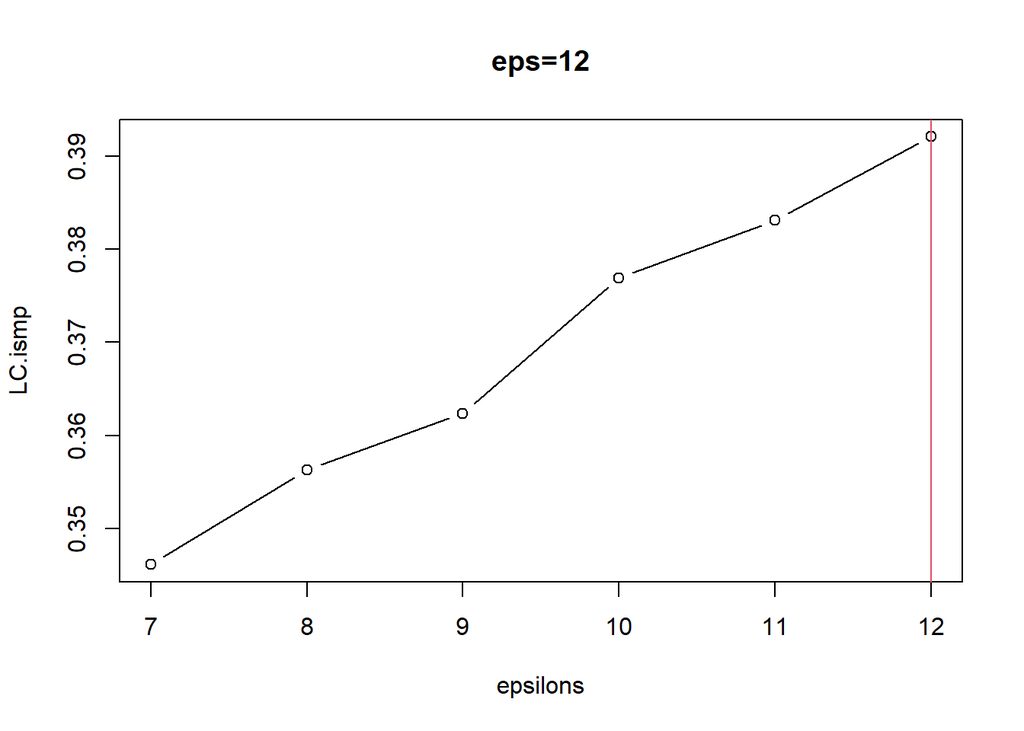

```r
epsilons <- seq(7, 12,by=1)
q=1
D1 <- dist(lgDifLE)
LC.ismp <- numeric(length(epsilons))

isomap_results <- vector("list",length(epsilons))

for (i in 1:length(epsilons)){
   eps <- epsilons[i]
   isomap_results[[i]] <- isomap(D1, ndim=q, eps=eps)
  dist_eps <- dist(isomap_results[[i]]$points[,1:q])
  LC.ismp[i] <- LCMC(D1, dist_eps, eps)$M.Kp.adj
}

i_max <- which.max(LC.ismp)
eps_max <- epsilons[i_max]
isomap_max <- isomap_results[i_max]

plot(epsilons, LC.ismp, type="b", main=paste0("eps=",round(eps_max,4)))
abline(v=eps_max,col=2)
```

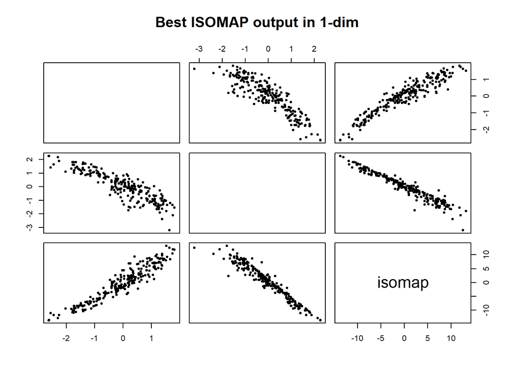

```r
best_k_isomap <- isomap(D1, ndim=q,  eps=eps_max)
pairs(cbind(X[,1:2] ,isomap=best_k_isomap$points[,1]), pch=20, main="Best ISOMAP output in 1-dim")
```

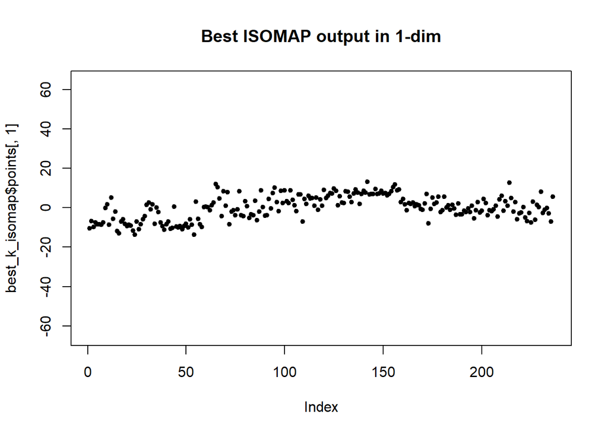

```r
plot(best_k_isomap$points[,1], pch=20, main="Best ISOMAP output in 1-dim", as=1)
```

```r
# todo how to add text
```

Select 3 countries located in the low dimensional space in such a way that they cover the variability of all the points in this dimension. Then plot their lgDifLE functions in a graphic as that in page 2.

How do you interpret the dimension obtained with ISOMAP?

**4.2** USING t-SNE. Use theta=0 in Rtsne function and choose perplexity in seq(10,50,by=10) as the value maximizing the correlation between the distance matrices in high and low dimensioal spaces.

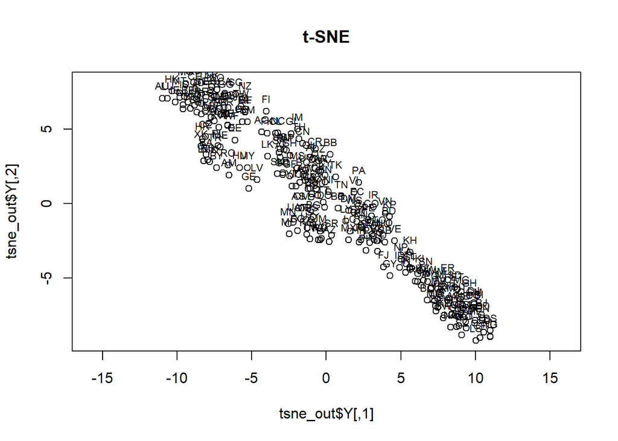

```r
library("Rtsne")
D=dist(as.matrix(X))

set.seed(42)
theta= 0.0
perp = 50
q=1

tsne_out <- Rtsne(D, pca=FALSE, perplexity=perp, theta=theta, q=1)

plot(tsne_out$Y, asp=1, main="t-SNE")
text(tsne_out$Y[,1], tsne_out$Y[,2], rownames(X), pos = 3, cex = .7)
```

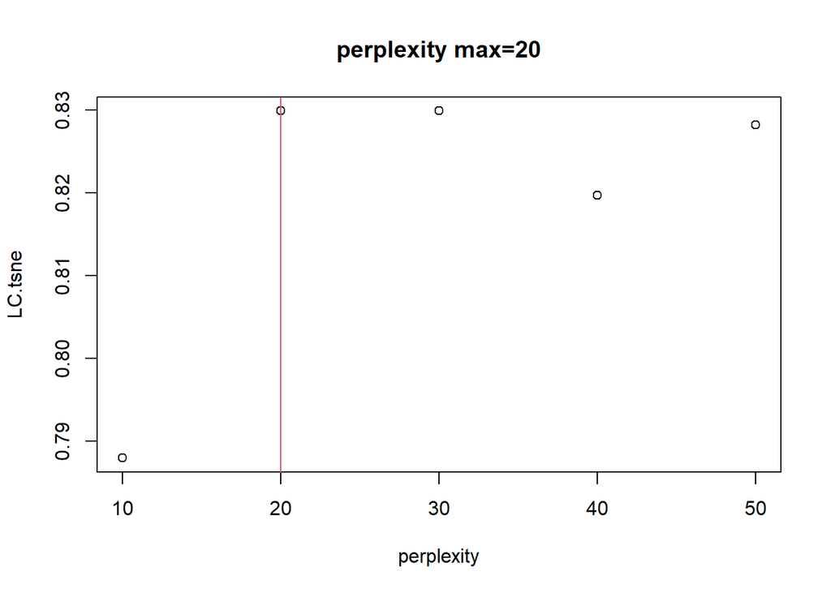

```r
require(Rtsne)
set.seed(4444)

D1 <- dist(X)
Kp <- 10
q <- 2
theta = 0

perplexity <- seq(10,50,by=10)

LC.tsne <- numeric(length(perplexity))
Rtsne.k <- vector("list",length(perplexity))

for (i in 1:length(perplexity)){
    Rtsne.k[[i]] <- Rtsne(D1, perplexity=perplexity[i], dims=q,
                          theta=0, pca=FALSE, max_iter = 1000)
    D2.k <- dist(Rtsne.k[[i]]$Y)
    LC.tsne[i] <- LCMC(D1,D2.k,Kp)$M.Kp.adj
}

i.max <- which.max(LC.tsne)
perplexity_max <- perplexity[i.max[1]]
best_rtsne <- Rtsne.k[[i.max]]

plot(perplexity,LC.tsne, main=paste0("perplexity max=",perplexity_max))
abline(v=perplexity[i.max],col=2)
```

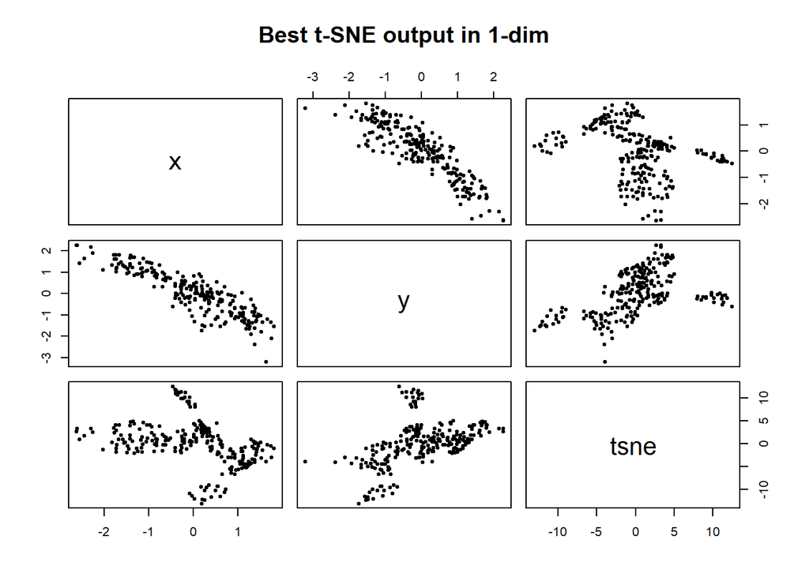

```r
pairs(cbind(x=X[,1], y=X[,2] ,tsne=best_rtsne$Y[,1]), pch=20, main="Best t-SNE output in 1-dim")
```

- Select 3 countries located in the low dimensional space in such a way that they cover the variability of all the points in this dimension. Then plot their lgDifLE functions in a graphic as that in page 2.

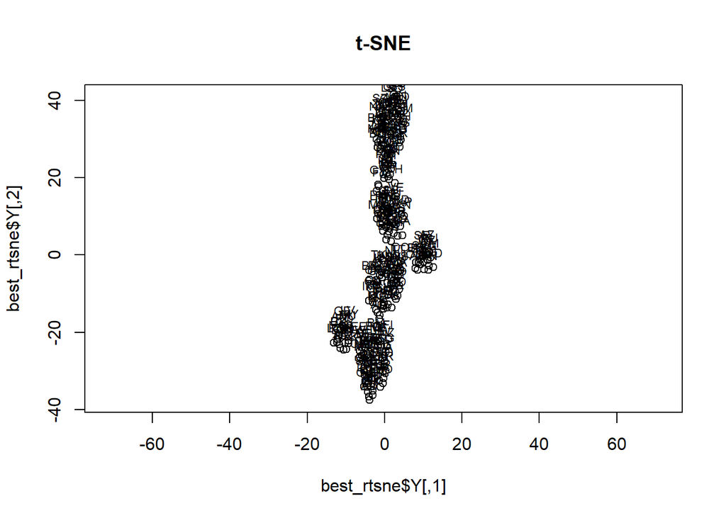

```r
plot(best_rtsne$Y, asp=1, main="t-SNE")
text(best_rtsne$Y[,1], best_rtsne$Y[,2], rownames(X), pos = 3, cex = .7)
```

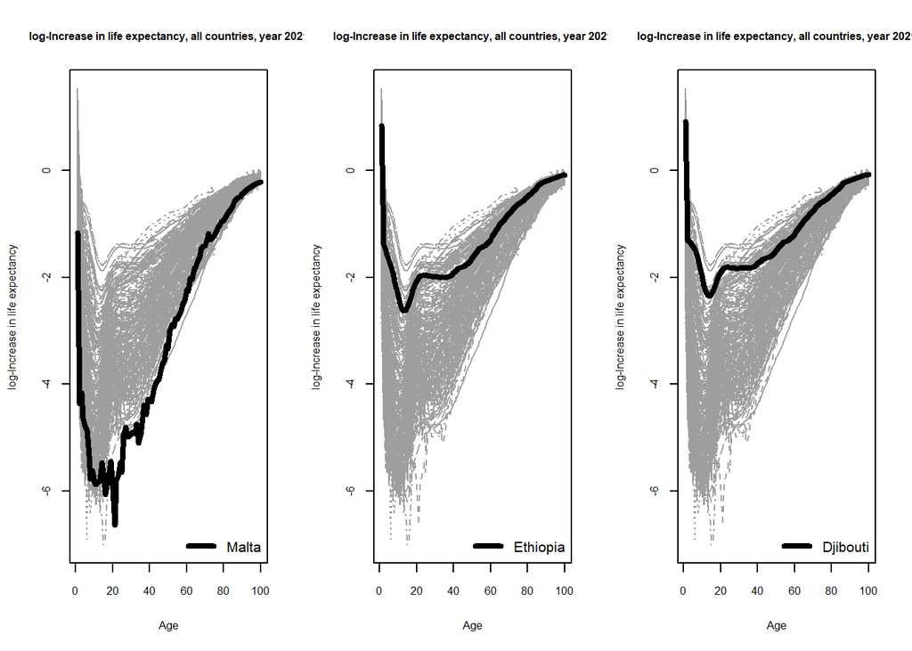

```r
sel_points = c("MT", "ET", "DJ")
op <- par(mfrow = c(1,3))

for (i in 1:3){
 matplot(1:100,t(lgDifLE), type="l",  col=8,
        xlab="Age",ylab="log-Increase in life expectancy",
        main="log-Increase in life expectancy, all countries, year 2021",
        cex.main=.75,cex.lab=.75,cex.axis=.75)

  i <- which(rownames(lgDifLE)==sel_points[i])
  lines(1:100,lgDifLE[i,],lwd=4, col=1)
  legend("bottomright",CtryName[i],lwd=4,col=1,bty="n")

}
```

- How do you interpret the dimension obtained with t-SNE?

**4.3** Do a pairs plot (that is, a matrix of scatterplots) of the matrix having the following 4 columns:

- LE[,1], that is, life expectancy at birth.
- First principal component of lgDifLE.
- 1-dimensional configuration obtained by isomap.
- 1-dimensional configuration obtained by t-SNE. Comment on the resulting graphic.

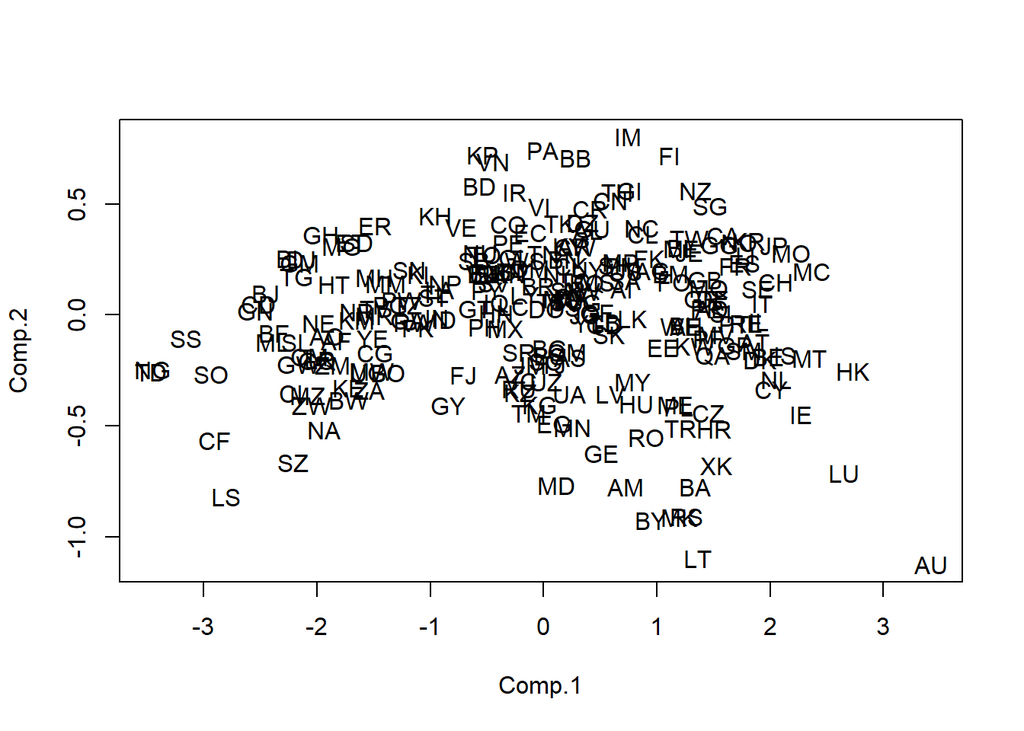

```r
# compare to PCA
pca_le = princomp(X)$scores
plot(pca_le, t='n')
text(pca_le, labels=rownames(X))
```